# Iris de Fisher

Marc XU

1 février 2019

```r
setwd("./../Marc")
getwd()
```

```
## [1] "/Users/marc/Desktop/Cours L3 S6/Stage/stageL3_2018-master/Marc/xx.Rproj/stageL3_2018/Marc"
```

# 1 Les iris de FISHER

## 1.1 Données : iris

```r
data(iris)
```

Variables : - longueur du sépale (Sepal.Length) - largeur du sépale (Sepal.Width) - longueur du pétale (Petal.Length) - largeur du pétale (Petal.Width) - nom de l’espèce (Species)

Mesures pour trois espèces d’iris : - Iris setosa - I. versicolor - I. virginica.

Les dimensions des jeux de données : il y a 150 lignes et 5 colonnes.

## 1.2 Représentation des espèces d’Iris

### 1.2.1 Modalités de la variable

```r
levels(iris$Species)
```

```
## [1] "setosa"     "versicolor" "virginica"
```

### 1.2.2 Nombre d’individus par modalité

```r
summary(iris$Species)
```

```
##     setosa versicolor  virginica
##         50         50         50
```

```r
# table(iris$Species)
```

### 1.2.3 Les différentes représentations

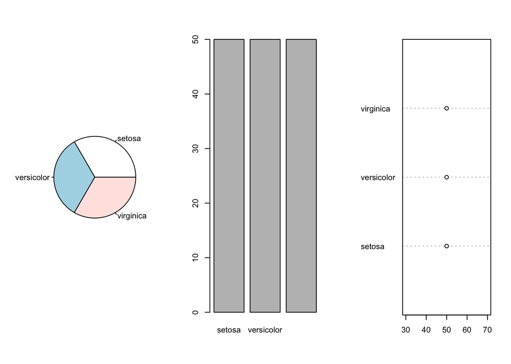

```r
par(mfrow= c(1, 3))
pie(table(iris$Species)) # représentation en secteur
barplot(table(iris$Species)) # représentation en bâtons
dotchart(table(iris$Species)) # représentation de Cleveland
```

**Exercice**

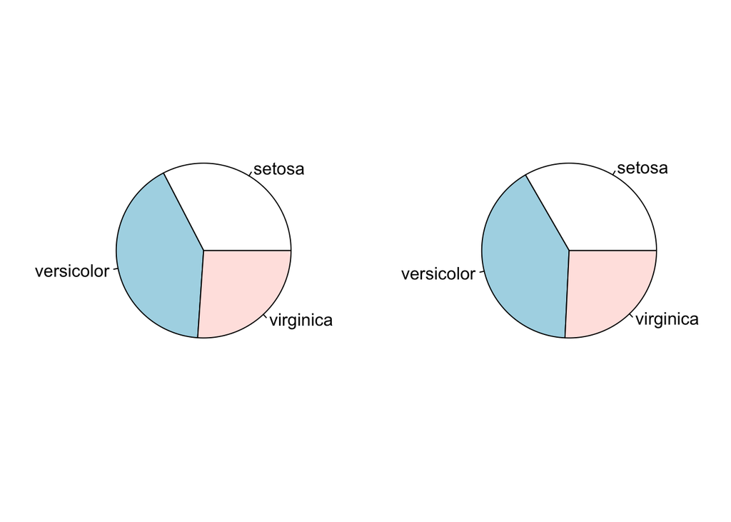

```r
collection1 <- rep(c("setosa", "versicolor", "virginica"), c(15, 19, 12))
collection2 <- rep(c("setosa", "versicolor", "virginica"), c(22, 27, 17))

par(mfrow = c(1, 2))
pie(table(collection1))
pie(table(collection2))
```

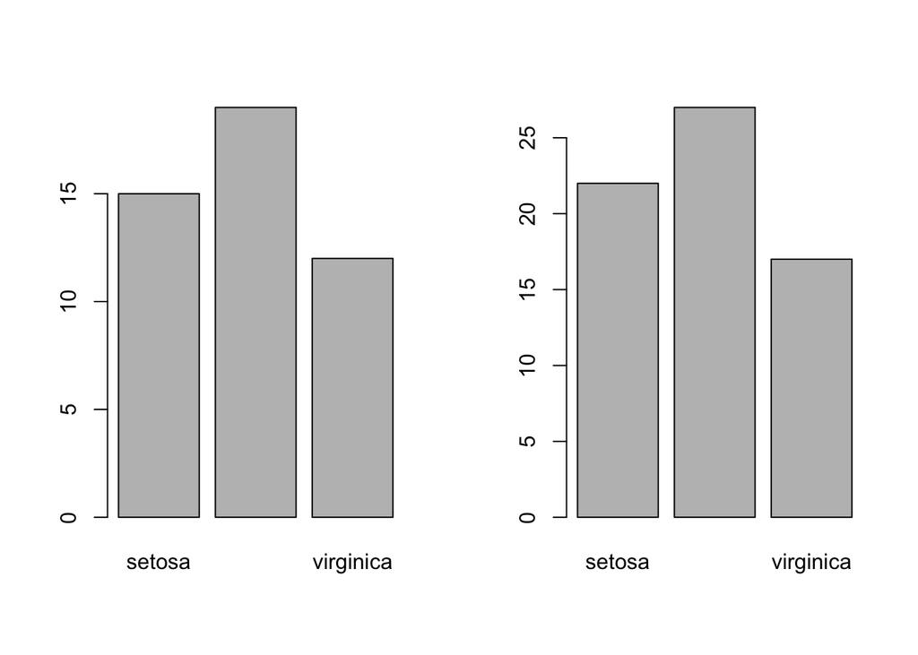

```r
barplot(table(collection1))
barplot(table(collection2))
```

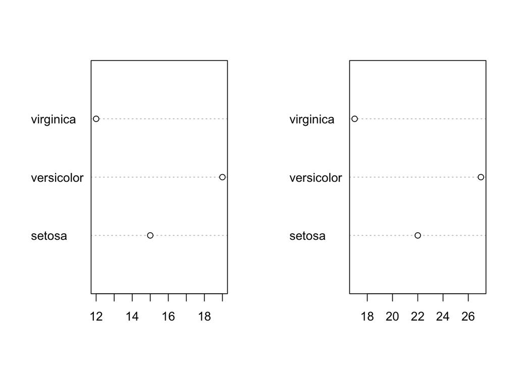

```r
dotchart(table(collection1))
dotchart(table(collection2))
```

##### 1.2.3.0.1 Commentaire :

- le camembert : il y a une répartition égale, car pour chaque variable, il n’est présent qu’une fois
  - Nous avons les variables
  - Cependant, la répartition ne reflète aucunement le jeu de données
- le bâton : représente les nombres d’individus, et on peut voir qu’il y a une différence entre les deux vecteurs
  - Nous avons les répartitions
  - Cependant, nous savons pas à quoi cela correspond
- Cleveland : pour chaque variable, il y a le nombre d’individus par variable
  - Nous avons les deux contraintes des deux précédentes représentation

## 1.3 Représentation de la longueur du pétale

### 1.3.1 Résumer l’information contenue dans cette variable

```r
summary(iris)
```

```
##   Sepal.Length    Sepal.Width     Petal.Length    Petal.Width
##  Min.   :4.300   Min.   :2.000   Min.   :1.000   Min.   :0.100
##  1st Qu.:5.100   1st Qu.:2.800   1st Qu.:1.600   1st Qu.:0.300
##  Median :5.800   Median :3.000   Median :4.350   Median :1.300
##  Mean   :5.843   Mean   :3.057   Mean   :3.758   Mean   :1.199
##  3rd Qu.:6.400   3rd Qu.:3.300   3rd Qu.:5.100   3rd Qu.:1.800
##  Max.   :7.900   Max.   :4.400   Max.   :6.900   Max.   :2.500
##        Species
##  setosa    :50
##  versicolor:50
##  virginica :50
##
##
##
```

**Exercice**

```r
min(iris$Petal.Length) # valeur minimale
max(iris$Petal.Length) # valeur maximale
sum(iris$Petal.Length) # somme des valeurs
length(iris$Petal.Length) # distribution
sum(iris$Petal.Length)/length(iris$Petal.Length) # moyenne
ordLpetal = sort(iris$Petal.Length) # toutes les valeurs de la distribution
```

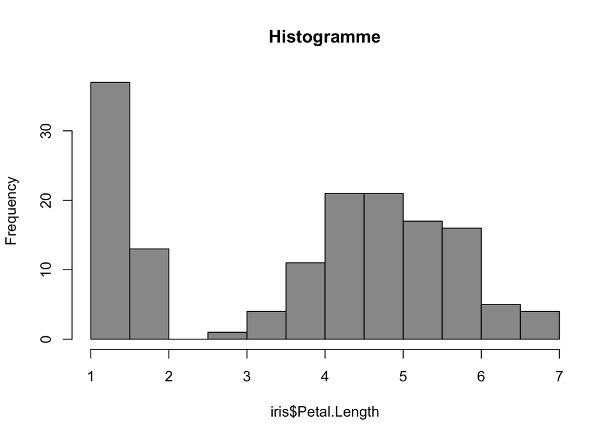

```r
hist(iris$Petal.Length, col = grey(0.6),
     main = "Histogramme")
```

**Valeur minimum**

```r
min(iris$Sepal.Width) # valeur minimale
```

```
## [1] 2
```

**Valeur maximal**

```r
max(iris$Sepal.Width) # valeur maximale
```

```
## [1] 4.4
```

**Somme des valeurs**

```r
sum(iris$Sepal.Width) # somme des valeurs
```

```
## [1] 458.6
```

**Distribution**

```r
length(iris$Sepal.Width) # distribution
```

```
## [1] 150
```

**Moyenne**

```r
sum(iris$Sepal.Width)/length(iris$Sepal.Width) # moyenne
```

```
## [1] 3.057333
```

```r
ordLpetal = sort(iris$Sepal.Width) # toutes les valeurs de la distribution
```

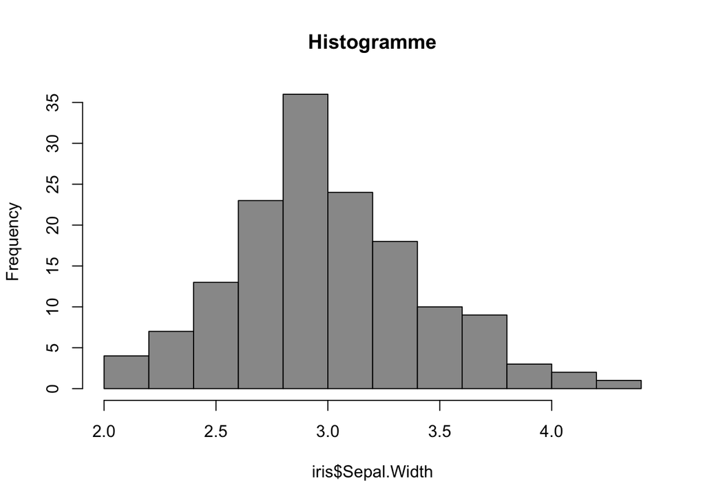

```r
hist(iris$Sepal.Width, col = grey(0.6), main = "Histogramme")
```

## 1.4 Représentation de la longueur et de la largeur du pétale

**Représentation en nuage de points**

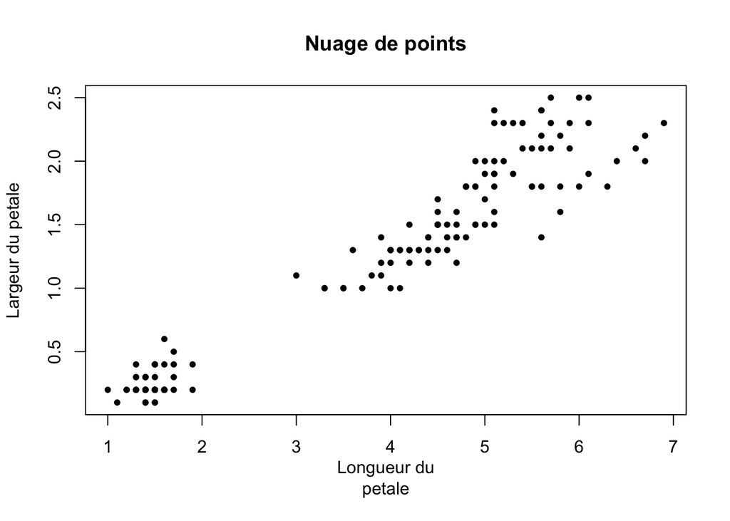

```r
plot(iris$Petal.Length, iris$Petal.Width,
     xlab = "Longueur du\npetale",
     ylab = "Largeur du petale",
     main = "Nuage de points",
     pch = 20)
```

**Représentation en nuage de points affichant les superpositions**

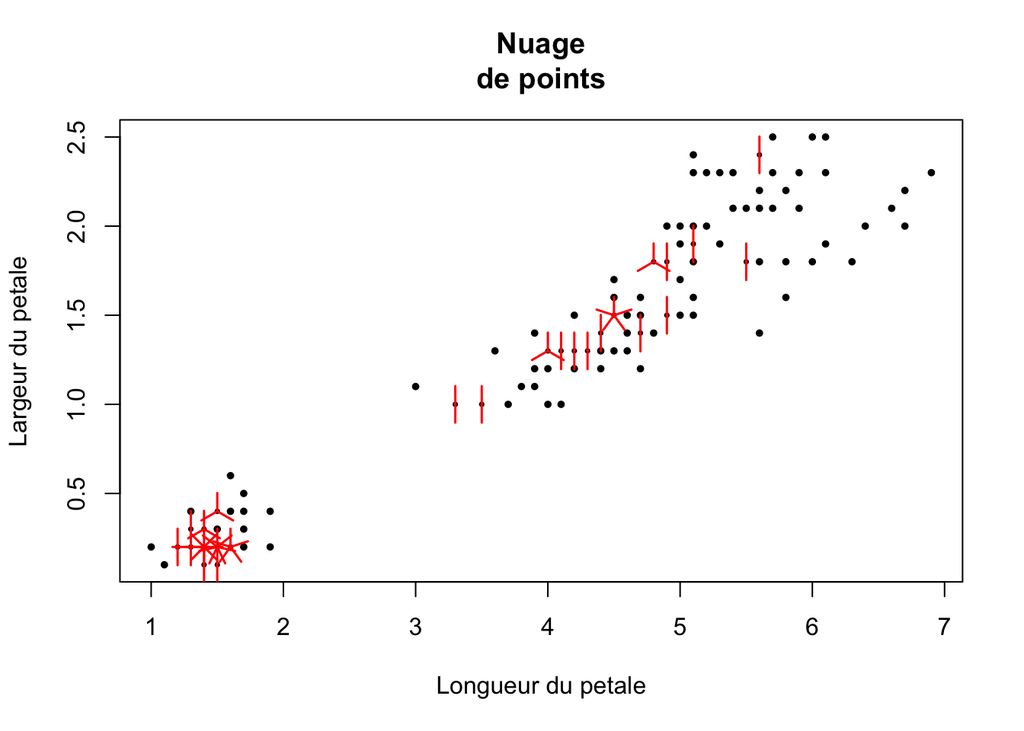

```r
sunflowerplot(iris$Petal.Length, iris$Petal.Width,
              xlab = "Longueur du petale",
              ylab = "Largeur du petale",
              main = "Nuage\nde points",
              pch = 20)
```

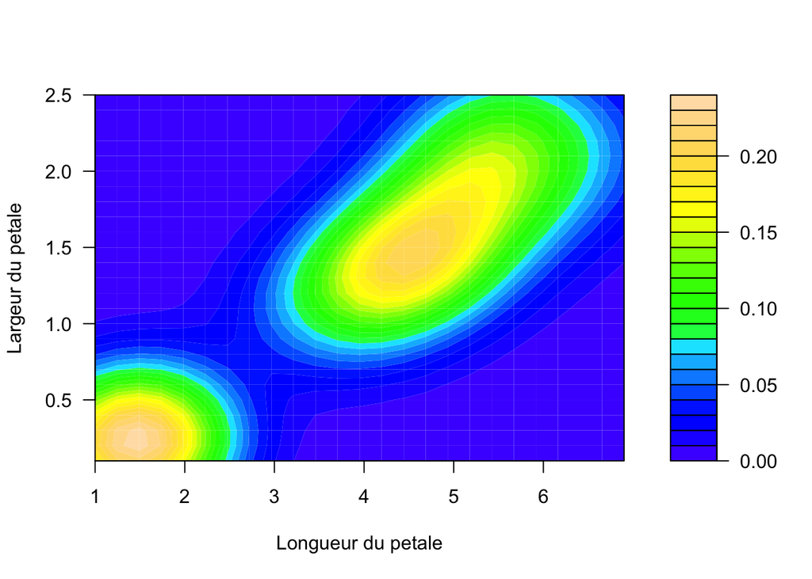

```r
library(MASS)
densite <- kde2d(iris$Petal.Length, iris$Petal.Width)
filled.contour(densite, color = topo.colors,
               xlab = "Longueur du petale",
               ylab = "Largeur du petale")
```

On peut réaliser l’étude avec la largeur de la sépale et la longueur de sépale

## 1.5 Représentation de la longueur du pétale selon les différentes espèces

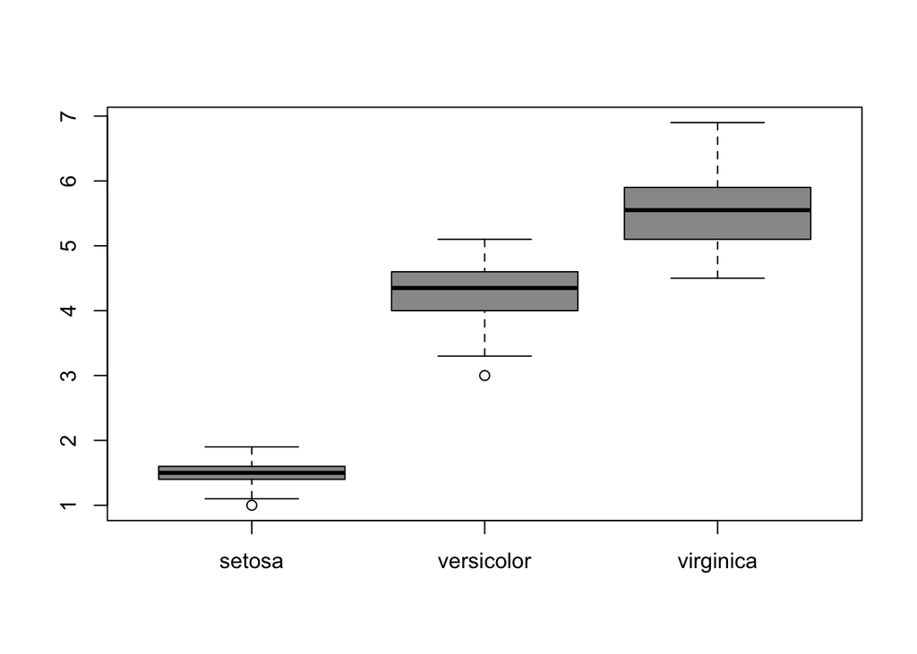

```r
boxplot(iris$Petal.Length ~ iris$Species, col = grey(0.6))
```

## 1.6 Pour aller plus loin . . .

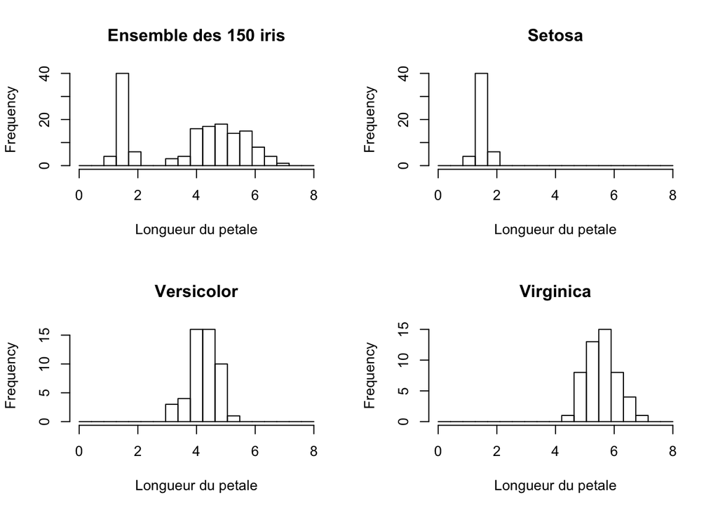

```r
par(mfrow = c(2, 2))
brk = seq(from = 0, to = 8, length = 20)
hist(iris$Petal.Length,
     main = "Ensemble des 150 iris",
     xlab = "Longueur du petale",
     breaks = brk)

hist(iris$Petal.Length[iris$Species == "setosa"],
     main = "Setosa",
     xlab = "Longueur du petale",
     breaks = brk)

hist(iris$Petal.Length[iris$Species == "versicolor"],
     main = "Versicolor",
     xlab = "Longueur du petale",
     breaks = brk)

hist(iris$Petal.Length[iris$Species == "virginica"],
     main = "Virginica",
     xlab = "Longueur du petale",
     breaks = brk)
```

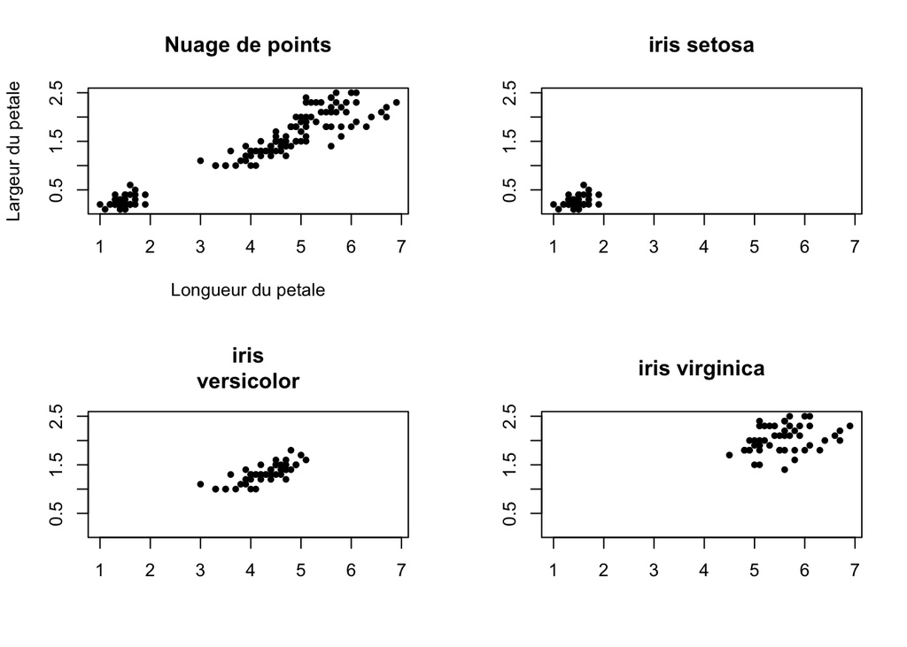

```r
par(mfrow = c(2, 2))
plot(iris$Petal.Length, iris$Petal.Width,
     xlab = "Longueur du petale", ylab = "Largeur du petale",
     main = "Nuage de points", pch = 20)

plot(iris$Petal.Length[iris$Species == "setosa"],
     iris$Petal.Width[iris$Species == "setosa"],
     xlim = c(1, 6.9), ylim = c(0.1, 2.5),
     xlab = "", ylab = "",
     main = "iris setosa", pch = 20)

plot(iris$Petal.Length[iris$Species == "versicolor"],
     iris$Petal.Width[iris$Species == "versicolor"],
     xlim = c(1, 6.9), ylim = c(0.1, 2.5),
     xlab = "", ylab = "",
     main = "iris\nversicolor", pch = 20)

plot(iris$Petal.Length[iris$Species == "virginica"],
     iris$Petal.Width[iris$Species == "virginica"],
     xlim = c(1, 6.9), ylim = c(0.1, 2.5),
     xlab = "", ylab = "",
     main = "iris virginica", pch = 20)
```

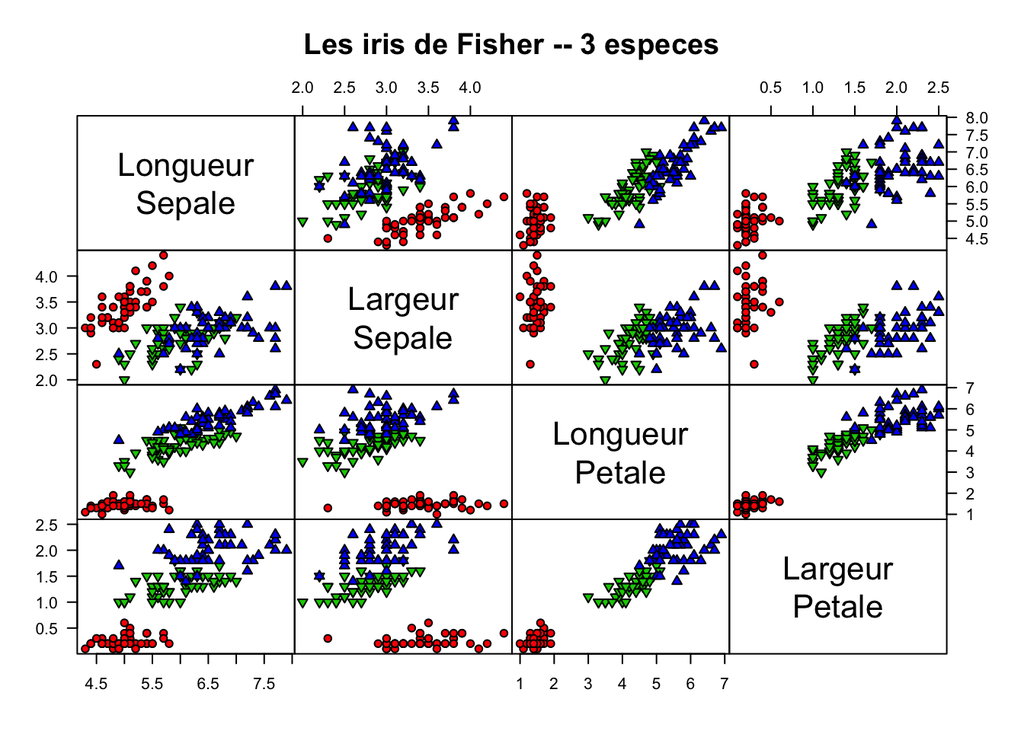

```r
spiris <- unclass(iris$Species)
pairs(iris[1:4], main = "Les iris de Fisher -- 3 especes",
      pch = c(21, 25, 24)[spiris],
      bg = c("red", "green3", "blue")[spiris],
      las = 1, gap = 0,
      labels = c("Longueur\nSepale",
                 "Largeur\nSepale",
                 "Longueur\nPetale",
                 "Largeur\nPetale"))
```